# 7 Drought metrics

```r
library(grassland)
theme_set(ggthemes::theme_few())
```

## Calculate CWD

Extract individual trait niche using TerraClim data where CWD data are available.

```r
dat_clim <- read_climate()
dat_trait_cwd <- calc_individual_trait(dat_occ, dat_clim, occ_source = "gbif", clim_source = "terraclim")
```

```r
dat_trait_cwd <- read_individual_trait(path_trait = "alldata/intermediate/climate-niche/gbif-terraclim.rds")
```

## Relationtionship between CWD and other climate variables

Plot relationship in niche space.

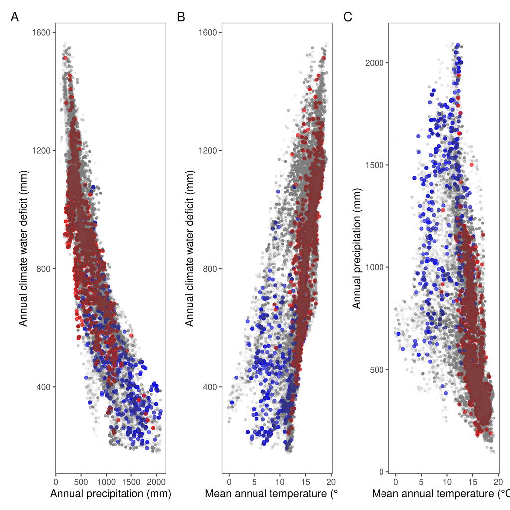

```r
gg_trait_cwd <- plot_trait_cwd(dat_trait_cwd)
gg_trait_cwd
```

```r
test_trait_cwd_cor(dat_trait_cwd)
```

```
#> $cwd_ppt
#>
#>  Pearson's product-moment correlation
#>
#> data:  cwd and ppt
#> t = -1436.7, df = 830065, p-value < 2.2e-16
#> alternative hypothesis: true correlation is not equal to 0
#> 95 percent confidence interval:
#>  -0.8451231 -0.8438891
#> sample estimates:
#>        cor
#> -0.8445072
#>
#>
#> $cwd_tmp
#>
#>  Pearson's product-moment correlation
#>
#> data:  cwd and tmp
#> t = 802.94, df = 830065, p-value < 2.2e-16
#> alternative hypothesis: true correlation is not equal to 0
#> 95 percent confidence interval:
#>  0.6599668 0.6623884
#> sample estimates:
#>       cor
#> 0.6611793
#>
#>
#> $ppt_tmp
#>
#>  Pearson's product-moment correlation
#>
#> data:  ppt and tmp
#> t = -695.24, df = 830065, p-value < 2.2e-16
#> alternative hypothesis: true correlation is not equal to 0
#> 95 percent confidence interval:
#>  -0.6079974 -0.6052783
#> sample estimates:
#>        cor
#> -0.6066396
```

Species occurrence in climate space of mean annual temperature (°C), annual precipitation (mm), and annual climate water deficit (mm) retrieved from the TerraClimate data (gray). Each point corresponds to a GBIF occurrence location. We highlight two example species *Danthonia californica* associated with cooler and wetter locations (blue) and *Stipa pulchra* associated with warmer and drier locations (red).

We found that across GBIF occurrence locations, P and CWD were highly correlated. Both variables were correlated with mean annual temperature (T), with CWD more strongly correlated to T compared to P’s correlation to T.

## Analyze community shift with CWD

Calculate species niche and community index.

```r
dat_niche_cwd <- calc_species_niche(dat_trait_cwd, add_dummy = T)
dat_index_cwd <- calc_community_index(dat_niche = dat_niche_cwd, dat_community = dat_community)
```

Plot community CWD index in comparison to CTI and CPI.

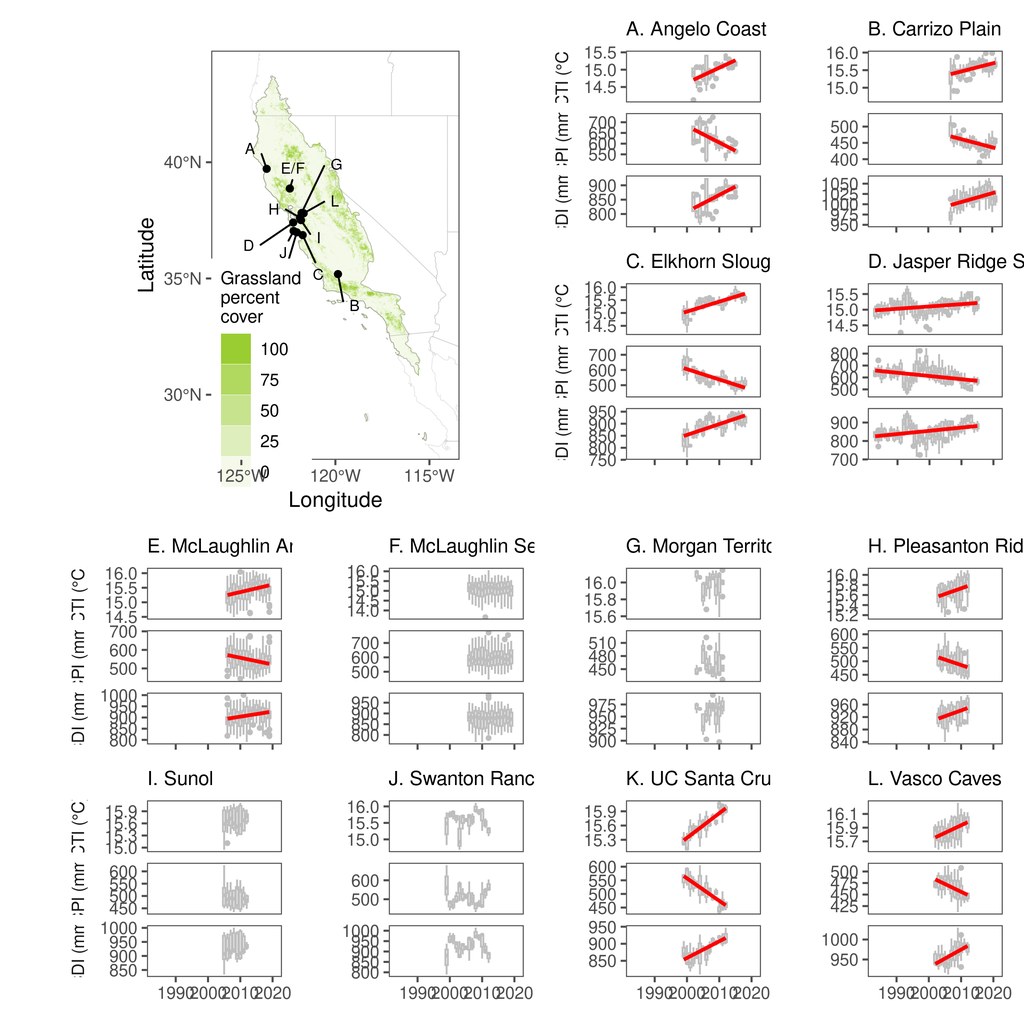

```r
gg_community_index_obs_cwd <- plot_community_index(option = "obs", dat_index = dat_index_cwd)
gg_community_index_obs_cwd
```

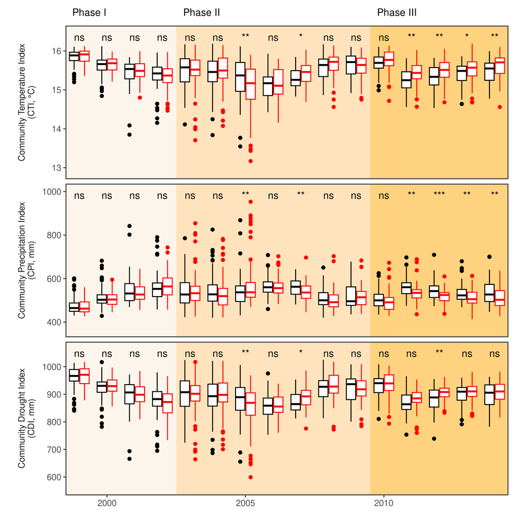

```r
gg_community_index_exp_cwd <- plot_community_index(option = "exp", dat_index = dat_index_cwd, experiment = "jrgce", treatment = "warming")
gg_community_index_exp_cwd
```

Consistent with climate warming and drying, grassland communities shift dominance to species associated with warmer (increasing CTI) and drier (decreasing CPI and increasing CDI) locations in 12 long-term observational sites across the California Floristic Province. In the Jasper Ridge Global Change Experiment, warming treatment caused communities to shift dominance to species associated with warmer (CTI) and drier (CPI and CDI) locations. Therefore, the additional drought metric CWD offered qualitatively similar insights from using precipitation.

Output figures and R data files.

```r
save_figure(out = list(
  trait_cwd = gg_trait_cwd,
  community_index_obs_cwd = gg_community_index_obs_cwd,
  community_index_exp_cwd = gg_community_index_exp_cwd
))
```